# EpiReserve - SIR Epidemic Mortality and Insurance Reserve Stress

Mira Gancheva

2026-03-19

## 1. Introduction

This project models the impact of an epidemic on life insurance reserves using the SIR (Susceptible-Infected-Recovered) compartmental model. During pandemics like COVID-19, insurers face unexpected excess mortality that can dramatically increase claims. This analysis quantifies that impact and calculates the additional reserves required.

## 2. The SIR Model

The SIR model divides a population of N individuals into three compartments:

- **S(t)**: Susceptible — healthy individuals who could get infected
- **I(t)**: Infected — currently sick and contagious individuals
- **R(t)**: Recovered/Removed — recovered or deceased individuals

The system is governed by three ordinary differential equations:

$$\frac{dS}{dt} = -aSI$$
$$\frac{dI}{dt} = aSI - bI$$
$$\frac{dR}{dt} = bI$$

where $a$ is the infection rate and $b$ is the recovery rate.

The basic reproduction number $R_0 = \frac{aN}{b}$ determines epidemic behavior:

- $R_0 > 1$: epidemic spreads
- $R_0 < 1$: epidemic dies out

Parameters were chosen to reflect a COVID-19 like scenario with $R_0 = 3$.

## 3. Epidemic Simulation

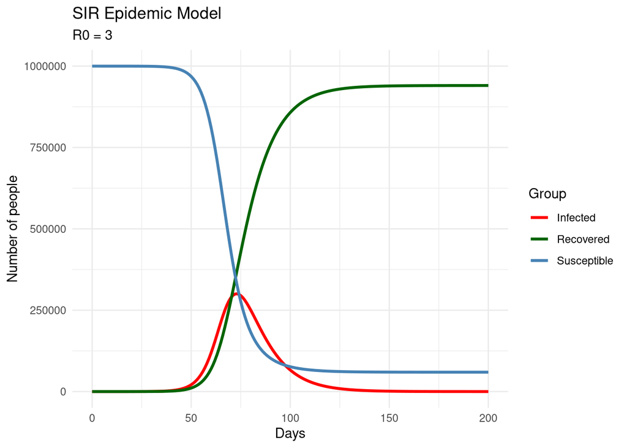

## 4. Mortality Analysis

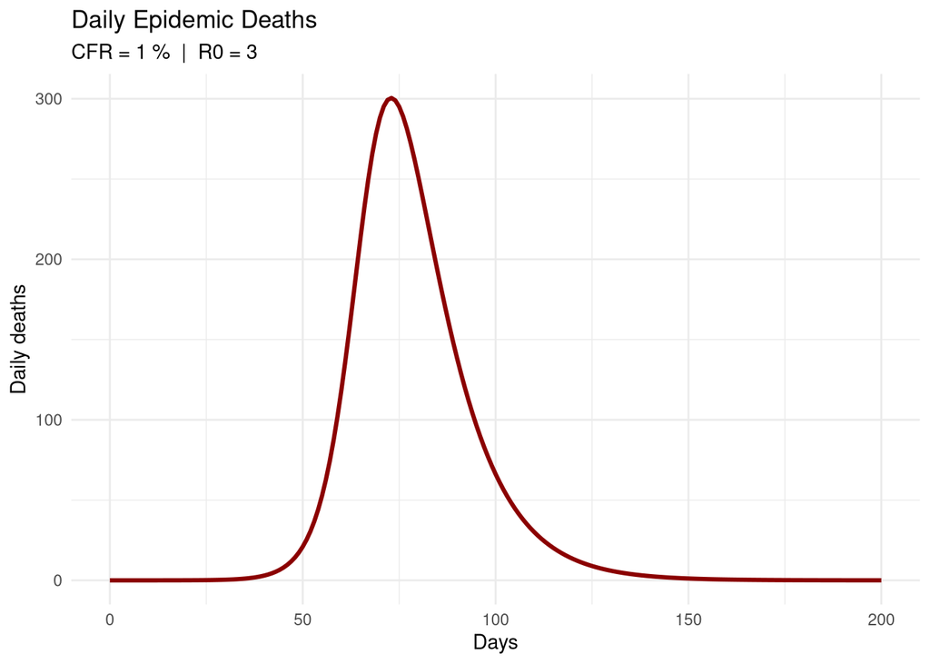

With a Case Fatality Rate of 1%, the epidemic produces:

- **Total epidemic deaths**: 9405
- **Peak daily deaths**: 300
- **Peak death day**: 74

## 5. Actuarial Reserve Impact

| Scenario | Deaths | Total Claims |
| --- | --- | --- |
| Baseline (no epidemic) | 40 | € 4e+06 |
| Epidemic stressed | 9445 | € 944,457,720 |

Key findings:

- **Extra claims from epidemic**: € 940,457,720
- **Reserve stress ratio**: 236.11x
- **Extra reserve per policy**: € 94,046

The reserve stress ratio of 236.11x means the insurer would need 236.11 times their normal reserve to cover claims during an epidemic of this severity.

## 6. Conclusion

This analysis demonstrates that even a moderate epidemic with $R_0 = 3$ can create reserve stress ratios exceeding 200x for a life insurance portfolio. Real actuaries would extend this model by:

- Using age-stratified mortality rates from DAV life tables
- Modelling partial immunity and vaccination effects
- Running sensitivity analysis across multiple R0 and CFR scenarios
- Applying regulatory stress tests as required by Solvency II

The interactive Shiny dashboard accompanying this report allows real-time exploration of how epidemic parameters affect insurance reserves.